# analysis of Ontario COVID19 data

## combined calibration

What if we want to estimate `beta0`, `E0`, and more than one breakpoint at the same time?

Break points

- [March 17th closures](https://news.ontario.ca/opo/en/2020/03/ontario-enacts-declaration-of-emergency-to-protect-the-public.html)
- [March 23rd closure](https://news.ontario.ca/opo/en/2020/03/ontario-closing-at-risk-workplaces-to-protect-health-and-safety.html)
- [March 23rd closures](https://news.ontario.ca/opo/en/2020/03/ontario-orders-the-mandatory-closure-of-all-non-essential-workplaces-to-fight-spread-of-covid-19.html)
- [March 28th prohibits gathering](https://news.ontario.ca/opo/en/2020/03/ontario-prohibits-gatherings-of-five-people-or-more-with-strict-exceptions.html)

The fit takes 88 seconds.

Initially tried to fit `c_prop` (proportion of cases reported) and `phi2` (proportion of ICU dying) but got ridiculous answers and non-pos-def Hessians: real non-identifiability or just wonky data? Or some outcome of some of the other shortcuts/problems in the fitting (e.g. equal dispersion parameters per variable)?

Estimated parameters:

```
## $params
##        E0     beta0        mu      phi1
## 8.6373637 1.4584282 0.9443127 0.6391953
##
## $rel_beta0
## [1] 0.3366358 0.8990636 0.2396676
##
## $nb_disp
## [1] 12.33823
```

There are strong positive correlations (0.9 - 0.97) among the breakpoint effects, and strong negative correlations (-0.97 - -0.99) between the breakpoint effects and the initial growth rate - this is presumably saying that the initial growth rate is very uncertain while the growth rates after the breakpoints (which are $\exp(\beta_0 + \Delta \beta_i)$) are relatively certain …

What are the implied R0 values here?

| date | r0 | R0 | Gbar | dbl_time |
| --- | --- | --- | --- | --- |
| 2020-02-29 | 0.339 | 4.899 | 6 | 2.043 |
| 2020-03-17 | 0.091 | 1.649 | 6 | 7.654 |
| 2020-03-23 | 0.312 | 4.404 | 6 | 2.223 |
| 2020-03-28 | 0.038 | 1.174 | 6 | 18.310 |

Now forecast using the fitted parameters.

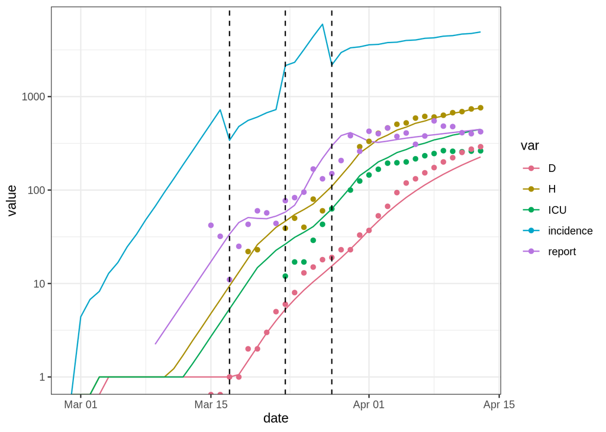

### forecast farther ahead

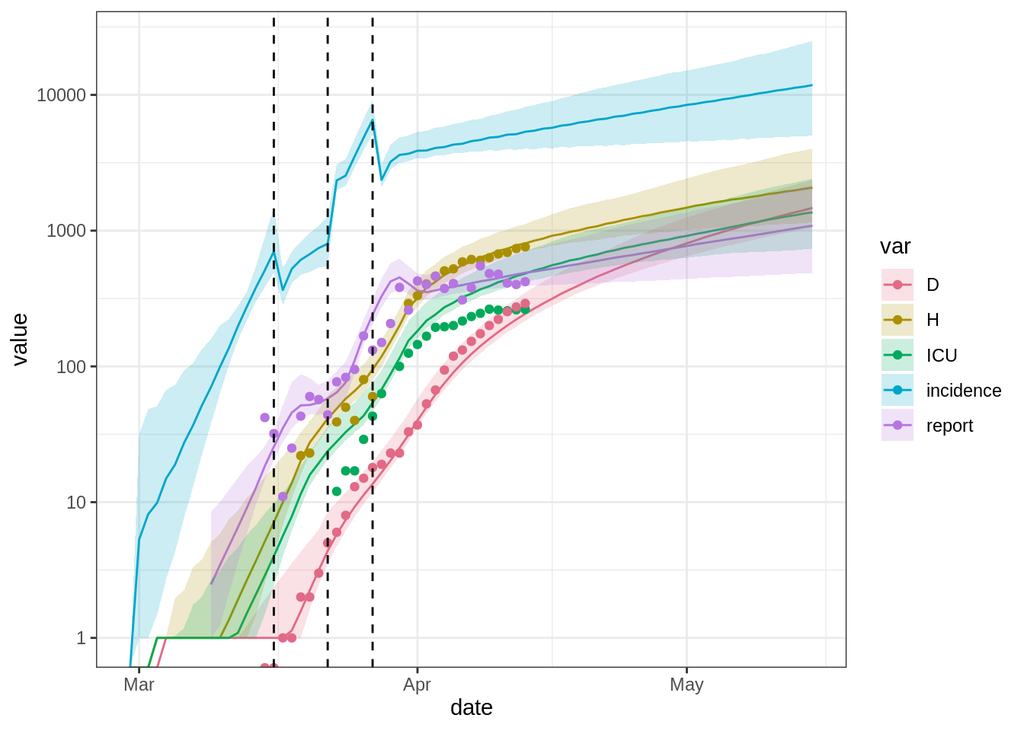

- have cheated here on displaying breakpoints (we *might* be off by one day?)
- confidence intervals not for public consumption (since they include only a subset of parametric uncertainty)
- As expected, since R0>1 at the end of our time series, the epidemic just keeps going …

## next

1. better/different approaches to estimating time-varying beta?